# Class11

Ethan Lai

2/23/2022

Let’s call library(DESeq2) and load our two data files

```r
library("DESeq2");
metadata<- read.csv(("airway_metadata.csv"))
counts<- read.csv("airway_scaledcounts.csv", row.names=1)
head(counts)
```

```
##                 SRR1039508 SRR1039509 SRR1039512 SRR1039513 SRR1039516
## ENSG00000000003        723        486        904        445       1170
## ENSG00000000005          0          0          0          0          0
## ENSG00000000419        467        523        616        371        582
## ENSG00000000457        347        258        364        237        318
## ENSG00000000460         96         81         73         66        118
## ENSG00000000938          0          0          1          0          2
##                 SRR1039517 SRR1039520 SRR1039521
## ENSG00000000003       1097        806        604
## ENSG00000000005          0          0          0
## ENSG00000000419        781        417        509
## ENSG00000000457        447        330        324
## ENSG00000000460         94        102         74
## ENSG00000000938          0          0          0
```

There are 38694 rows, ie “genes” in this dataset

```r
metadata
```

```
##           id     dex celltype     geo_id
## 1 SRR1039508 control   N61311 GSM1275862
## 2 SRR1039509 treated   N61311 GSM1275863
## 3 SRR1039512 control  N052611 GSM1275866
## 4 SRR1039513 treated  N052611 GSM1275867
## 5 SRR1039516 control  N080611 GSM1275870
## 6 SRR1039517 treated  N080611 GSM1275871
## 7 SRR1039520 control  N061011 GSM1275874
## 8 SRR1039521 treated  N061011 GSM1275875
```

It looks like we have four treated (ie with drug) and four control (ie no drug). Does the drug do anything?

We want to compare treated vs control.

Fist, let’s make sure the metadata matches the counts data order

```r
all(metadata$id ==colnames(counts))
```

```
## [1] TRUE
```

Let’s get going!

First, let’s take a summary statistic of all controls vs all treated:

```r
#metadata[metadata$dex=="control", "id"]

controls<- counts[metadata$dex=="control"]
treateds<- counts[metadata$dex=="treated"]
head(controls)
```

```
##                 SRR1039508 SRR1039512 SRR1039516 SRR1039520
## ENSG00000000003        723        904       1170        806
## ENSG00000000005          0          0          0          0
## ENSG00000000419        467        616        582        417
## ENSG00000000457        347        364        318        330
## ENSG00000000460         96         73        118        102
## ENSG00000000938          0          1          2          0
```

```r
head(treateds)
```

```
##                 SRR1039509 SRR1039513 SRR1039517 SRR1039521
## ENSG00000000003        486        445       1097        604
## ENSG00000000005          0          0          0          0
## ENSG00000000419        523        371        781        509
## ENSG00000000457        258        237        447        324
## ENSG00000000460         81         66         94         74
## ENSG00000000938          0          0          0          0
```

Now that we have our control and treated data separated, we’ll find the mean count values for each row ie gene. We could use `apply()` or more simply `rowMeans()`

```r
control.means<- rowMeans(controls)
treated.means<-rowMeans(treateds)
```

Let’s plot control vs treated means:

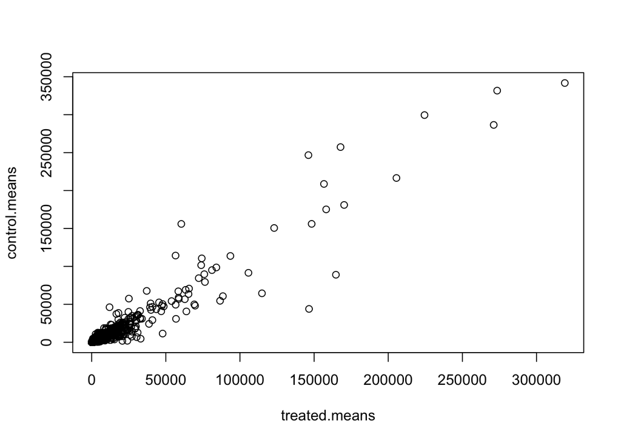

```r
plot( treated.means, control.means,)
```

Most of the data is in the bottom left. Let’s make it a log-log plot

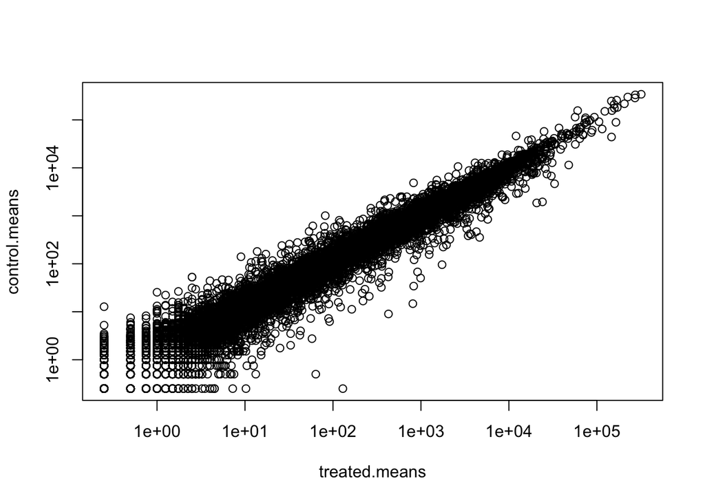

```r
plot( treated.means, control.means, log="xy")
```

We often use log transformation because it is more intuitive:

```r
log2(20/20)
```

```
## [1] 0
```

Zero fold change

```r
log2(40/20)
```

```
## [1] 1
```

1 fold log change, meaning doubling.

Let’s cvompute the log2 fold change

```r
log2fc <- log2(treated.means/control.means)
```

Let’s make a data.frame to store our results to data:

```r
meancounts<-data.frame(control.means, treated.means, log2fc)
head(meancounts)
```

```
##                 control.means treated.means      log2fc
## ENSG00000000003        900.75        658.00 -0.45303916
## ENSG00000000005          0.00          0.00         NaN
## ENSG00000000419        520.50        546.00  0.06900279
## ENSG00000000457        339.75        316.50 -0.10226805
## ENSG00000000460         97.25         78.75 -0.30441833
## ENSG00000000938          0.75          0.00        -Inf
```

We need a way to remove NaN and -Inf: We use the which() function in a complicated one-liner.

```r
to.rm<- unique(which(meancounts[,1:2]==0, arr.ind=TRUE)[,"row"])
mycounts<- meancounts[-to.rm,]
```

Q1. How many genes do we have left? Q2. How many have a log2fc more than 2?

```r
remainingGenes<- nrow(mycounts)
```

There are 21817 genes left.

```r
greater<- sum(mycounts$log2fc>=2)
```

There are 314 genes with log2fc >2